# ZOZOテクノロジーズ新卒採用 1次課題

Koki Ando

2019-01-29

# 1次課題: ファッションECにおけるレコメンドエンジン

## 設問

> ファッションECの特徴をうまく利用したエンジンを作る想定で以下の問いに答えてください。
- ファッションアイテムを扱うECで観測される「購買ログ」にはどんな特性が存在すると思いますか？ 商材ごとにEC上におけるユーザーの購買行動は変化すると考えることは自然な発想です。観測されるデータの背後で起こっていると思われる現象と絡めて説明してください。 本問はレコメンドの経験を問うものではありません。自由に想像して回答してください。 (参考までに、一般的なECで得られるデータのサンプルを提示します。これのほか、実際のECで扱っていると思われるデータやSNSなど外部のデータソースと組み合わせて回答しても構いません。)
- どんなアルゴリズムが有効だと思いますか？ 1.で説明した特性を利用したレコメンドアルゴリズムを開発し、ECの売上向上を目指します。 どんなアルゴリズムが有効だと思いますか？アルゴリズムの概要および効果的だと考える理由を説明して下さい。
- 2.で説明したレコメンドアルゴリズムを実装してください。 一般に公開されているベンチマーク、もしくは自作したダミーデータを用いてアルゴリズムの稼働確認をして下さい。ただし、稼働確認に用いるデータはファッションに関係していなくても構いませんし、1.で説明した特性を満たしている必要もありません。 (本問は目的に対して手段を正しく選択できていることを重視するため、高度なアルゴリズムである必要はありません。目的に対して手段を正しく選択できるかを重視するため高度なアルゴリズムである必要はない。)

# ファッションアイテムを扱うEC上での購買ログにはどのような特徴が存在するのか？

1. **ユーザーは当初の目的であった優先順位の高い商品を買ってから、その後に付随して違うアイテムを探す。**
2. **性別、年代、地域によってユーザーの購買アイテムが大きく異なっていく。**

自分はこの問いに対して、普段自分がどのような行動をEC上で行なっているか、ということを想起するところから始めた。自分は通常**一つ以上の目的の商品を思い浮かべてからECを訪れている**。ユーザーの中には、ウィンドーショッピング目的で訪れ、そこで気になった商品があるとクリックして購買するというユーザーも多いであろうが、自分にはそのケースは当てはまらない。そのため、今回の分析レポートの分析対象からはそのようなユーザーを外すことにした。

自分の場合、必ず一つの求めていた商品を見つけた後に、関連商品やその他セール対象になっている商品なども探し、複数個の商品をカートにプールして決済を行う。自分のこのようなEC上での行動経験をもとにファッションアイテムを扱うECで観測される「購買ログ」には以下の特徴が大きくあると考える。

ファッションアイテムを扱うEC上での購買ログにはどのような特徴が存在するのか？ 自分はこの問いに対して、普段自分がどのような行動をオンラインショッピングサイトで行なっているか、ということを想起するところから始めた。 自分は普段、ECサイトを訪れる際に、何か目的を持っている。中には、単なるウィンドーショッピング目的で訪れ、そこで気になった商品があるとクリックして購買するというユーザーも多いであろうが、自分にはそのケースは当てはまらないため、今回の分析レポートの分析対象からは外すとした。 自分の場合、必ず一つの求めていた商品を見つけた後に、関連商品やその他セール対象になっている商品なども探し、複数個の商品をカートにプールして決済を行う。 自分のこのようなECサイト上での行動経験をもとに以下の特徴が大きくあると仮定した。 ユーザーは最も優先順位の高い商品を買うのみではなく、それに関連した商品も探し、同時に決済することが多い。 以上の仮説をもとに分析レポートを作成していく。

# どんなアルゴリズムが有効か？

1.で説明した特性を利用したレコメンドアルゴリズムを開発し、ECの売上向上を目指します。 どんなアルゴリズムが有効だと思いますか？アルゴリズムの概要および効果的だと考える理由を説明して下さい。

# レコメンドアルゴリズムを実装してください。

一般に公開されているベンチマーク、もしくは自作したダミーデータを用いてアルゴリズムの稼働確認をして下さい。ただし、稼働確認に用いるデータはファッションに関係していなくても構いませんし、1.で説明した特性を満たしている必要もありません。 (本問は目的に対して手段を正しく選択できていることを重視するため、高度なアルゴリズムである必要はありません。目的に対して手段を正しく選択できるかを重視するため高度なアルゴリズムである必要はない。)

### キーとなる分析指標

このレポートでは、売上のパターンを発掘するためにこの統計手法を用いる。“cross-selling opportunities”を見つける。例)商品Aを購入した顧客は商品Bも共に購入する傾向がある。

## 使用するライブラリー

```r
library(DT)
library(tidyverse)
library(data.table)
```

## 使用するデータ

[Bread Basket data](https://github.com/viktree/curly-octo-chainsaw/blob/master/requirements.txt) スコットランドのBread Basket社が以前提供していた匿名顧客の2016年10月30日から2017年4月9日までの購買データをもとに分析を行う。

```r
transactions_df <- read.csv("BreadBasket_DMS.csv")
```

#### Probabilities

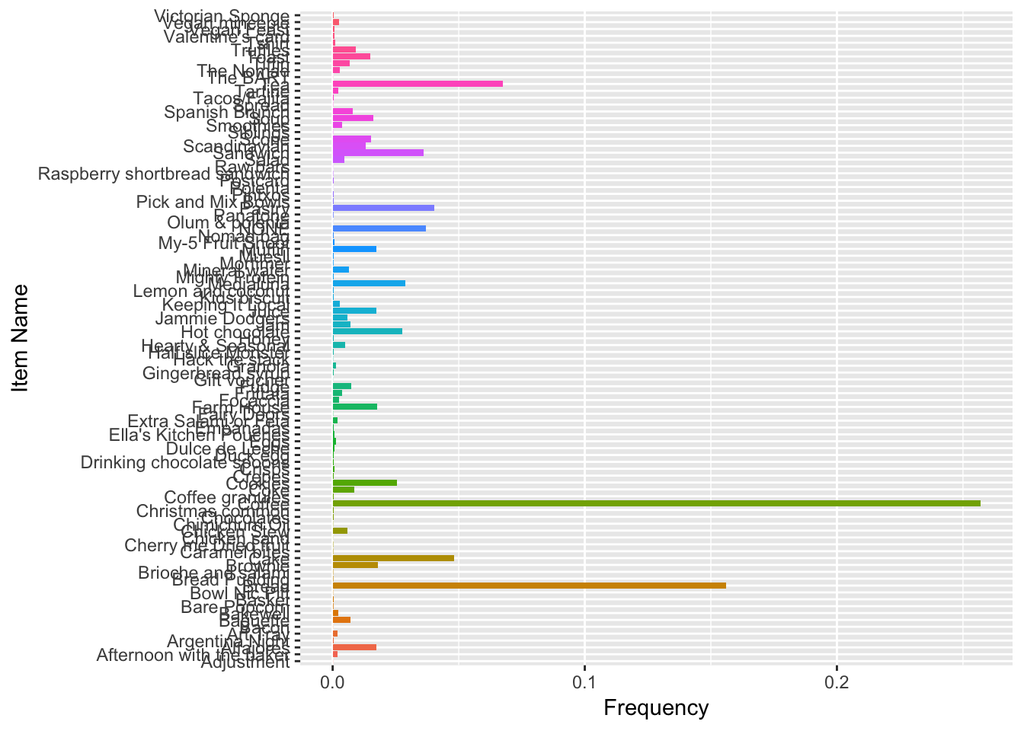

```r
Probability_df <- data.frame(table(transactions_df$Item)) %>%
  mutate(Pro = round(Freq/sum(Freq), digits = 5))

Probability_df %>%
  # head(20) %>%
  ggplot(aes(x = Var1, y = (Freq/nrow(transactions_df)), fill = Var1)) +
  geom_bar(stat = "identity", show.legend = FALSE) +
  coord_flip() +
  labs(x = "Item Name", y = "Frequency")
```

#### Support & Confidence

probability that a customer will buy two items (A & B) together

```r
support_df <- read.csv("support_df.csv")
#上記に使っているデータを整形して、購買商品の組み合わせを作ったデータフレームをインポート
# データ整形の過程は外部リンク参照(https://github.com/koki25ando/insurance/blob/master/cleasingofbread.R)
```

```r
confidence <- function(first_item){
   pro_of_first_item <- Probability_df %>%
    filter(Var1 == first_item)
   Pobability_of_item  <- pro_of_first_item$Pro
   print(paste0("Probability of the item: ", Pobability_of_item))

   sup_con_dat  <- support_df[support_df$Var1 %like% first_item, ] %>%
     mutate(Confidence = Support/Pobability_of_item) %>%
     head(10)
   print(sup_con_dat)

   sup_con_dat$Var1 <- sup_con_dat$Var1 %>%
     str_remove(first_item) %>%
     str_remove(", ")
   print(sup_con_dat)
   pro_of_recommend_item  <- Probability_df %>%
     filter(Var1 %in% sup_con_dat$Var1)
   merge(sup_con_dat, pro_of_recommend_item, by = "Var1") %>%
     mutate(Lift = Confidence/Pro)
}
confidence(first_item="Bread")
```

```
## [1] "Probability of the item: 0.15615"
##     X                  Var1 Freq     Support  Confidence
## 1   2                 Bread 1528 0.163930909 1.049829707
## 2  22         Coffee, Bread   75 0.008046347 0.051529599
## 3  27         Bread, Coffee   53 0.005686085 0.036414250
## 4  42          Bread, Bread   19 0.002038408 0.013054165
## 5  49         Bread, Pastry   15 0.001609269 0.010305920
## 6  53            Bread, Tea   12 0.001287416 0.008244736
## 7  62            Tea, Bread   10 0.001072846 0.006870613
## 8  66      Bread, Medialuna    8 0.000858277 0.005496491
## 9  67         Bread, Muffin    8 0.000858277 0.005496491
## 10 69 Coffee, Coffee, Bread    8 0.000858277 0.005496491
##     X           Var1 Freq     Support  Confidence
## 1   2                1528 0.163930909 1.049829707
## 2  22         Coffee   75 0.008046347 0.051529599
## 3  27         Coffee   53 0.005686085 0.036414250
## 4  42          Bread   19 0.002038408 0.013054165
## 5  49         Pastry   15 0.001609269 0.010305920
## 6  53            Tea   12 0.001287416 0.008244736
## 7  62            Tea   10 0.001072846 0.006870613
## 8  66      Medialuna    8 0.000858277 0.005496491
## 9  67         Muffin    8 0.000858277 0.005496491
## 10 69 CoffeeCoffee,     8 0.000858277 0.005496491
```

```
##        Var1  X Freq.x     Support  Confidence Freq.y     Pro       Lift
## 1     Bread 42     19 0.002038408 0.013054165   3325 0.15615 0.08360016
## 2    Coffee 27     53 0.005686085 0.036414250   5471 0.25694 0.14172278
## 3    Coffee 22     75 0.008046347 0.051529599   5471 0.25694 0.20055110
## 4 Medialuna 66      8 0.000858277 0.005496491    616 0.02893 0.18999276
## 5    Muffin 67      8 0.000858277 0.005496491    370 0.01738 0.31625378
## 6    Pastry 49     15 0.001609269 0.010305920    856 0.04020 0.25636617
## 7       Tea 62     10 0.001072846 0.006870613   1435 0.06739 0.10195301
## 8       Tea 53     12 0.001287416 0.008244736   1435 0.06739 0.12234361
```

## Confidence

probability that customer buys B, given that they already bought A

## Lift

ratio of confidence to the base probability of just buying items

# Limitations

- 使用したデータは食品でありさらには、保存が効かない商品についてだった。その為季節性の激しいさらには長持ちする衣類を対象にすると思うような効果を出せない可能性もある。
- さらには一般的に衣類はブランド品から日用品といったものまで幅広い価格帯の商品が多く、さらには季節性も激しいと思われる。

# Challenges to overcome

- 商品の価格帯が大きく変動するので、ユーザーごとにクラスタリングしたのちに、クラスターごとの購買ログから上述したパターン認識を行い商品をレコメンドするといった手法も実行可能ではありそう。実際のデータがあれば是非とも挑戦したいと思った。
- このレポートで用いたように扱う商品が多くなればなるほどなかなか組み合わせというものは見つけづらいかも知れない。その為、サンプルデータで提供されていたような小カテゴリやブランドといった要因で同時に購入される商品の組み合わせを発掘して、レコメンドするという方法も可能であると思われる。

以上。安藤光希

# 参考文献リスト

- [STITCH FIX Tech Blog](https://multithreaded.stitchfix.com/blog/)
- [レコメンドの研究者、Julian McAuleyのサイト](https://cseweb.ucsd.edu/~jmcauley/)
- [国際会議 ECCV 2018 workshop 採択論文](https://sites.google.com/view/eccvfashion/papers)
- [国際会議 ICCV 2017 workshop Computer Vision For Fashion](https://sites.google.com/zalando.de/cvf-iccv2017/)
- [mhahsler/Arurles](https://github.com/mhahsler/arules)
- [MBA by Xavier](https://www.kaggle.com/xvivancos/market-basket-analysis)
- [intro](http://r-statistics.co/Association-Mining-With-R.html)
- [intro pdf](https://cran.r-project.org/web/packages/arules/vignettes/arules.pdf)
- [R-Bloggers](https://www.r-bloggers.com/association-rules-and-market-basket-analysis-with-r/)